# team

Eric Friesth, Aashwin Lamsal

11/12/2019

## Processing the data

```r
library(tidyverse)
df = read.table('diabetes.txt', header=TRUE)

df[df==""]<-NA #replacing empty strings with NA's

df = droplevels(df) #using droplevels as specified in the spec


removed_cols <- c("id","bp.2s", "bp.2d")
diabetes_reduced <- df %>% select(-removed_cols) #dropping the id, bp.2s, and bp.2d columns
#view(diabetes_reduced)

index.na=apply(is.na(diabetes_reduced), 1, any) # used to identify rows with missing value.

diabetes_clean<- na.omit(diabetes_reduced) #na.omit drops all rows with any NA Values
```

5. The way that we check if step four was done correctly, we used sum and is.na to see the number of rows with NA values, as seen below.

```r
print(sum(is.na(diabetes_clean)))
```

```
## [1] 0
```

## Exploring and Transforming data

6. You can fix the right skewness of glyhb by setting the x limits of the plot using + xlim(), the downside of using this is we ignore outliers that lie to the right of the distribution thus removing 44 rows.

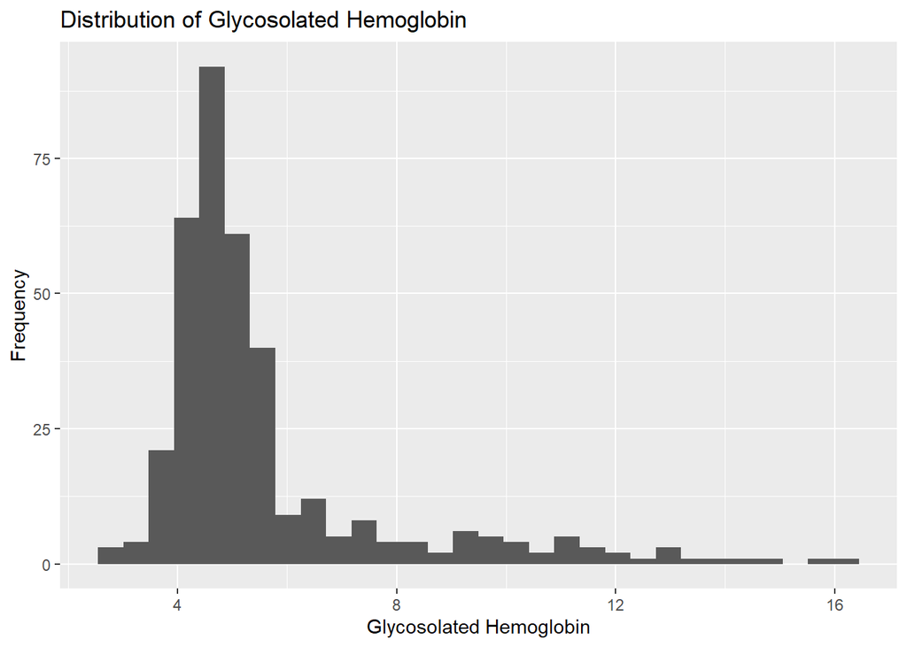

```r
library(dplyr)

ggplot(diabetes_clean, aes(x = glyhb)) + geom_histogram() + labs(title = "Distribution of Glycosolated Hemoglobin", x = "Glycosolated Hemoglobin", y = "Frequency") # plotted a histogram of the variable glyhb to see the skewness
```

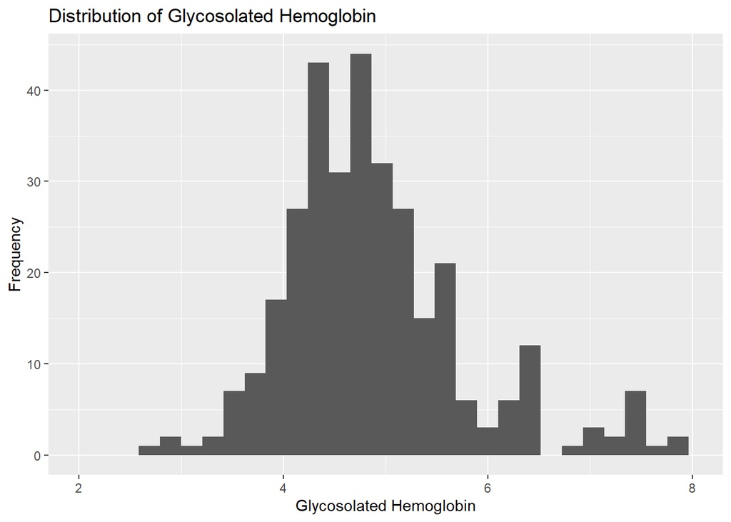

```r
ggplot(diabetes_clean, aes(x = glyhb)) + geom_histogram() + xlim(2, 8) + labs(title = "Distribution of Glycosolated Hemoglobin", x = "Glycosolated Hemoglobin", y = "Frequency") # set limits on the x axis to create a better looking distribution without the outliers greater than 8
```

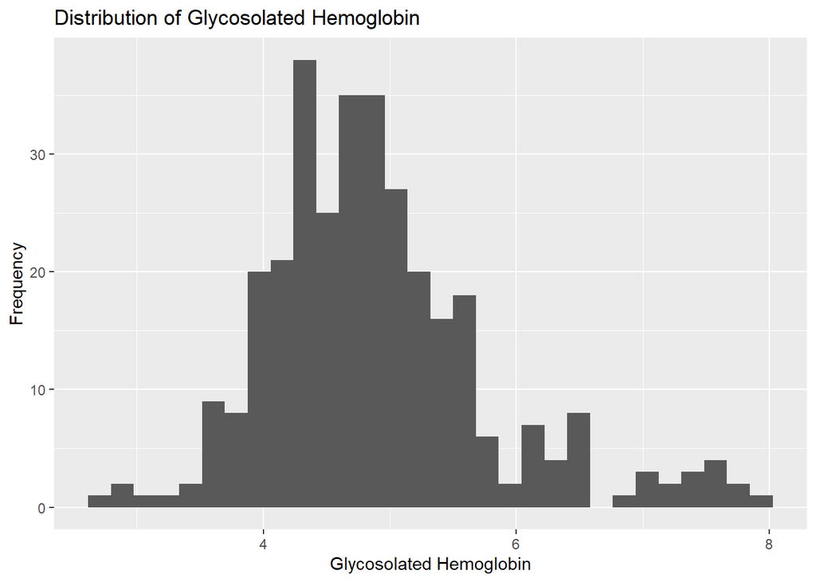

```r
diabetes_clean$glyhb[diabetes_clean$glyhb > 8] <- NA # applies NA to any glyhb being greater than 8

diabetes_clean = na.omit(diabetes_clean) # dropped those new 44 rows

names(diabetes_clean)[names(diabetes_clean) == 'glyhb'] <- 'glyhb_star' # renamed that column to be glyhb_star

ggplot(diabetes_clean, aes(x = glyhb_star)) + geom_histogram() + labs(title = "Distribution of Glycosolated Hemoglobin", x = "Glycosolated Hemoglobin", y = "Frequency")
```

Summary Statistics of glyhb_star

```r
summary(diabetes_clean$glyhb_star) #summary of the variable glyhb_star
```

```
##    Min. 1st Qu.  Median    Mean 3rd Qu.    Max.
##   2.680   4.345   4.760   4.889   5.240   7.910
```

```r
diabetes_clean %>% group_by(frame)%>% summarise(mean(glyhb_star)) # looking at the mean values of glyhb_star by the frames (small medium and large)
```

```
## # A tibble: 3 x 2
##   frame  `mean(glyhb_star)`
##   <fct>               <dbl>
## 1 large                5.31
## 2 medium               4.87
## 3 small                4.54
```

## Visualizations

```r
library(ggplot2)

diabetes_clean %>% group_by(frame,location) %>% summarise (mean.glyhb_star= mean(glyhb_star))
```

```
## # A tibble: 6 x 3
## # Groups:   frame [3]
##   frame  location   mean.glyhb_star
##   <fct>  <fct>                <dbl>
## 1 large  Buckingham            5.53
## 2 large  Louisa                4.98
## 3 medium Buckingham            4.95
## 4 medium Louisa                4.81
## 5 small  Buckingham            4.54
## 6 small  Louisa                4.54
```

# glyhb_star against ratio

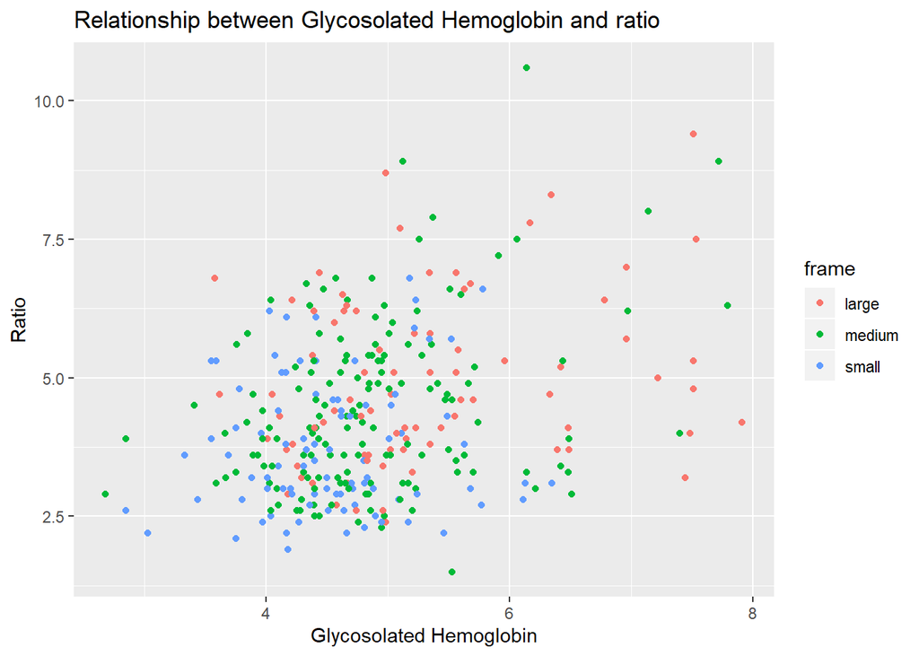

```r
ggplot(diabetes_clean, aes(glyhb_star, ratio, color = frame)) + geom_point() + labs(x= "Glycosolated Hemoglobin", y="Ratio", title = "Relationship between Glycosolated Hemoglobin and ratio")
```

# glyhb_star against bp.1s

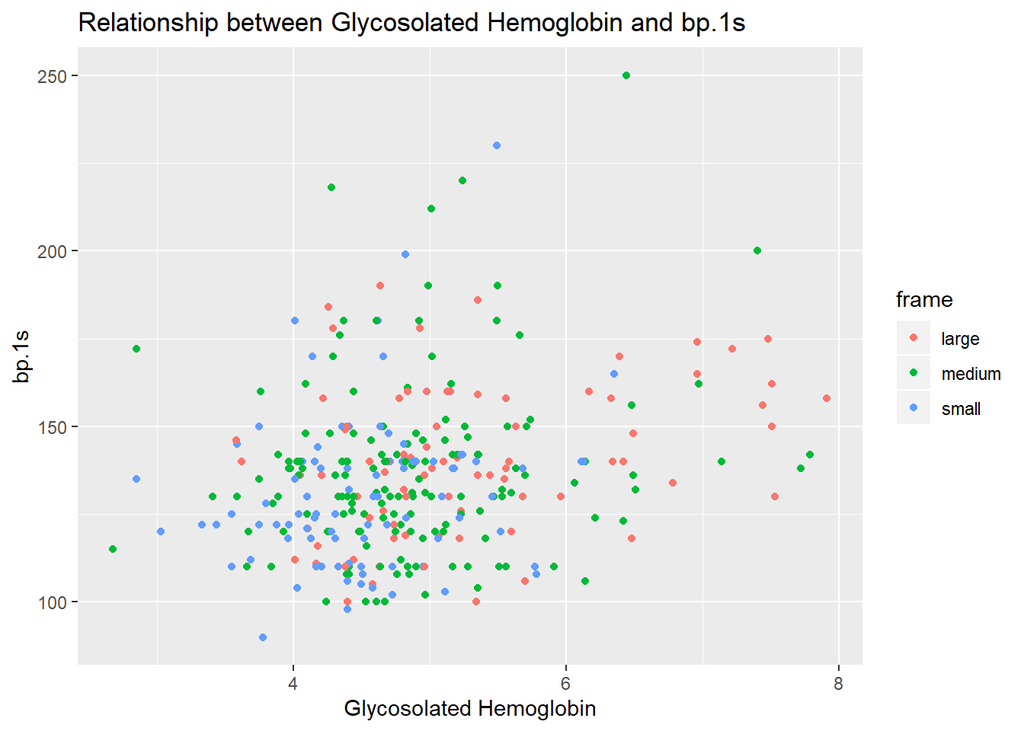

```r
ggplot(diabetes_clean, aes(glyhb_star, bp.1s, color = frame)) + geom_point() + labs(x= "Glycosolated Hemoglobin", y="bp.1s", title = "Relationship between Glycosolated Hemoglobin and bp.1s")
```

# glyhb_star against age

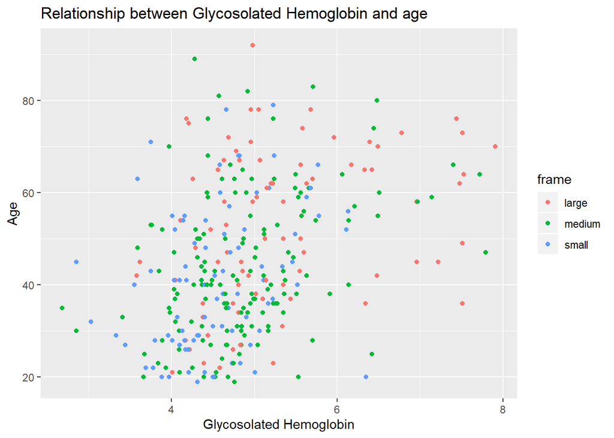

```r
ggplot(diabetes_clean, aes(glyhb_star, age, color = frame)) + geom_point() + labs(x= "Glycosolated Hemoglobin", y="Age", title = "Relationship between Glycosolated Hemoglobin and age")
```

# glyhb_star against gender

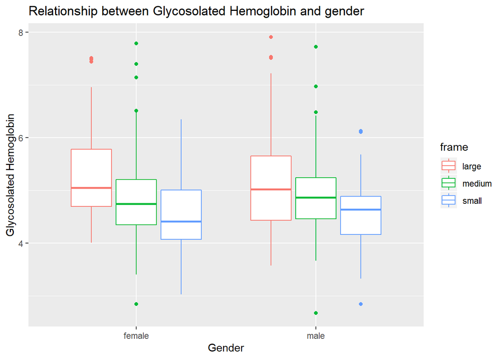

```r
ggplot(diabetes_clean, aes(gender, glyhb_star, color = frame)) + geom_boxplot() + labs(x= "Gender", y="Glycosolated Hemoglobin", title = "Relationship between Glycosolated Hemoglobin and gender")
```

# glyhb_star against hip

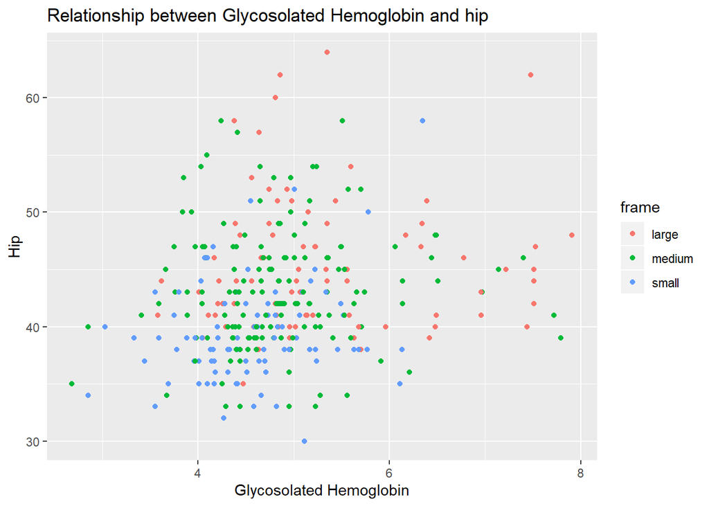

```r
ggplot(diabetes_clean, aes(glyhb_star, hip, color = frame)) + geom_point() + labs(x= "Glycosolated Hemoglobin", y="Hip", title = "Relationship between Glycosolated Hemoglobin and hip")
```

# glyhb_star against weight

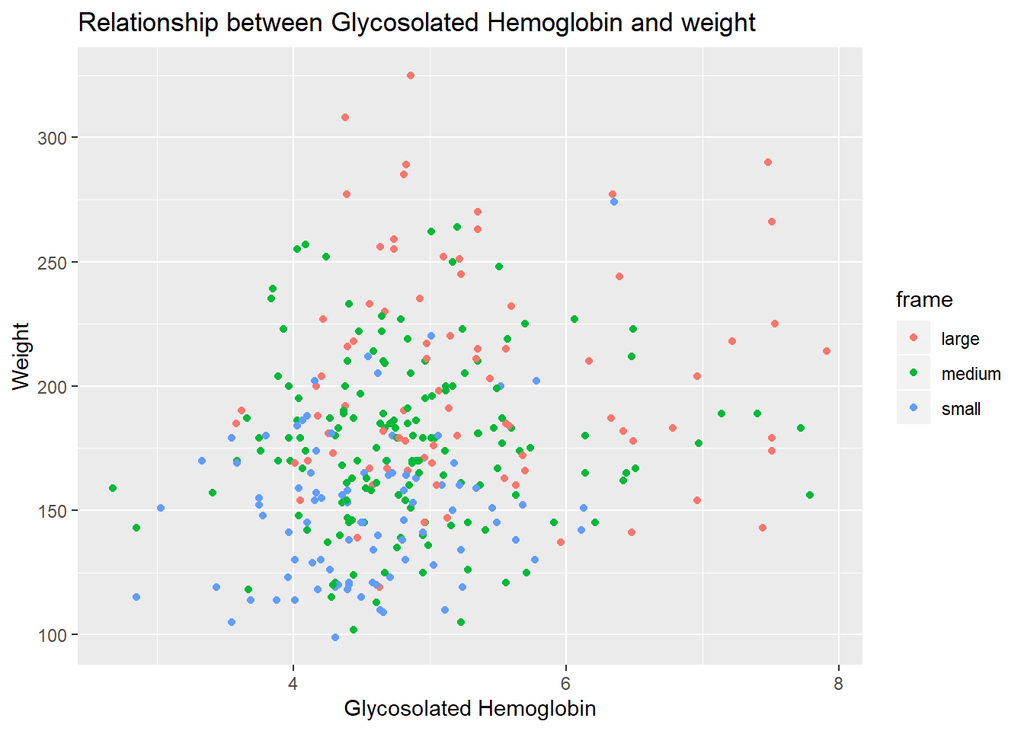

```r
ggplot(diabetes_clean, aes(glyhb_star, weight, color = frame)) + geom_point() + labs(x= "Glycosolated Hemoglobin", y="Weight", title = "Relationship between Glycosolated Hemoglobin and weight")
```

## Messy Data

13. The function gather() is used to make tables more narrow in width and longer in length while the function spread() is used to do the opposite with a dataset, make it longer in width and shorter in length. More specifically, these functions are used to reformat the dataset to view it in a different way (stacking).
14. These functions are related in that they both reformat your data to make it more readable. They complement each other on the common Key and Value.

## Regression Models

```r
fit = lm(glyhb_star ~stab.glu + age + waist + ratio+ factor(frame),data=diabetes_clean)

summary(fit)
```

```
##
## Call:
## lm(formula = glyhb_star ~ stab.glu + age + waist + ratio + factor(frame),
##     data = diabetes_clean)
##
## Residuals:
##      Min       1Q   Median       3Q      Max
## -2.31689 -0.49065 -0.05421  0.40338  2.54725
##
## Coefficients:
##                      Estimate Std. Error t value Pr(>|t|)
## (Intercept)          2.623230   0.391885   6.694 9.96e-11 ***
## stab.glu             0.007921   0.001444   5.486 8.46e-08 ***
## age                  0.013023   0.002716   4.794 2.52e-06 ***
## waist                0.018357   0.008659   2.120  0.03478 *
## ratio                0.089187   0.030105   2.963  0.00328 **
## factor(frame)medium -0.147499   0.109815  -1.343  0.18019
## factor(frame)small  -0.276407   0.136111  -2.031  0.04312 *
## ---
## Signif. codes:  0 '***' 0.001 '**' 0.01 '*' 0.05 '.' 0.1 ' ' 1
##
## Residual standard error: 0.7447 on 315 degrees of freedom
## Multiple R-squared:  0.3118, Adjusted R-squared:  0.2987
## F-statistic: 23.79 on 6 and 315 DF,  p-value: < 2.2e-16
```

15. Judging from the results of our model, we an see that the mean value of the glycosolated hemoglobin (abbreviated to GH from this point forward) is 2.62 approximately, meaning that the level of GH is 2.62 when the stabilized glucose, age, waist, medium frame, small frame, and ratio values are equal to 0. The 0.0079 estimate value for stabilized glucose shows that when the value of the stabilized glucose level increases by a measure of 1, the mean GH level will increase by 0.79%. Similarly, the estimates of 0.013, 0.018, 0.089, -0.147, and -0.276 for age, waist, ratio, medium frame, and small frame respectively goes to show the varying changes of the mean value of GH based on those predictors respectively, while keeping every other predictor constant.

With regard to the adjusted R squared, the value that tells us how much the change in our response variable is explained by the predictors by measuring the proportion of variability in the response that can be explained using the predictors, and the F-statistic , the value that checks the existence of some sort of relationship (linear or logistic, in this case linear) be between the response and predictor variables, we see that the adjusted R squared value is a bit too low to show any correlation between the GH and predictors that we used in the model. With regard to the F-statistic and the P-value, we see that the P-value is very small and the F-statistic being 23.79, this leads us to believe that at least one of our six predictors is related and significant to the GH level.

The results from our exploratory analysis suggest that a linear model may not be the right approach. We had a hunch early on that this would be the case while making the scatter plots showing the correlation of this dataset’s variables. The scatter plots showed very little, if any, correlation so a linear model wouldn’t be a good approach.

16. Interpretting the coefficients shows us the change in the mean value of GH based on an increase of 1 unit in a predictor while all others remain constant (explained below):
- 0.7% from an increase of 1 in stablized glucose, with all other predictors being constant
- 1.3% from an increase of 1 in age, with all other predictors being constant
- 1.8% from an increase of 1 in waist, with all other predictors being constant
- 8.9% from an increase of 1 in ratio, with all other predictors being constant
- (-14.75)% from an increase of 1 in medium frame, with all other predictors being constant
- (-27.64)% from an increase of 1 in small frame, with all other predictors being constant
17. We can interpet the y hat value as the predicted value of y, our response variable, in a regression equation. Running the following code block shows the predicted y-values:

```r
view(fit$fitted.values)
```

## Reflection

20. Our views of how important and applicable data science is has not changed but we do believe we have a broader knowlege of how applicable it is. We now know that data scientist use the exploration of structured and unstructured data to make inferences and predictive models to predict new data aka new observations.

1- The most surprising thing we find about data science is the wide range of uses such as predictive models, AI, data visualization, etc. The many uses creating knowledge has is infinite.

2- The most challenging thing we find about data science is trying to translate what you’re trying to do to the syntax of the programs you’re using as well as some of the more conceptual terms that you need to know going into it (i.e. y-hat, summary statistics, etc).

3- The most interesting thing we find with using data science is that the uses are kind of endless because now in day-to-day life and can think about predicting future values of something if I can collect past instances. Data Science techniques can be applicable in many different subject areas which makes it fun to be contantly learning something new. Also it feels good when everything runs and works hahaha.